# Titanic

## Visualization: Exploratory data analysis

### Now let’s run some visualizations to deepen our understanding of the variables

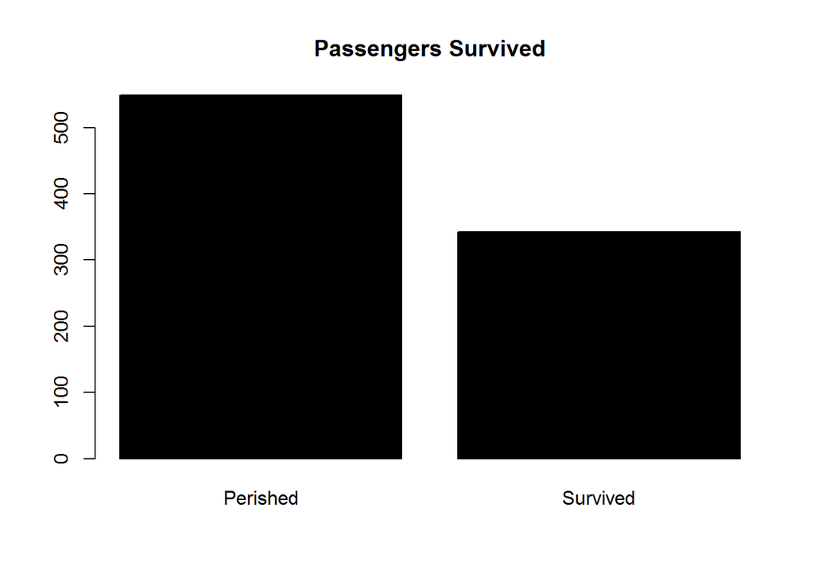

```r
barplot(table(train.data$Survived), main = "Passengers Survived", names = c("Perished","Survived"), col ="black")
```

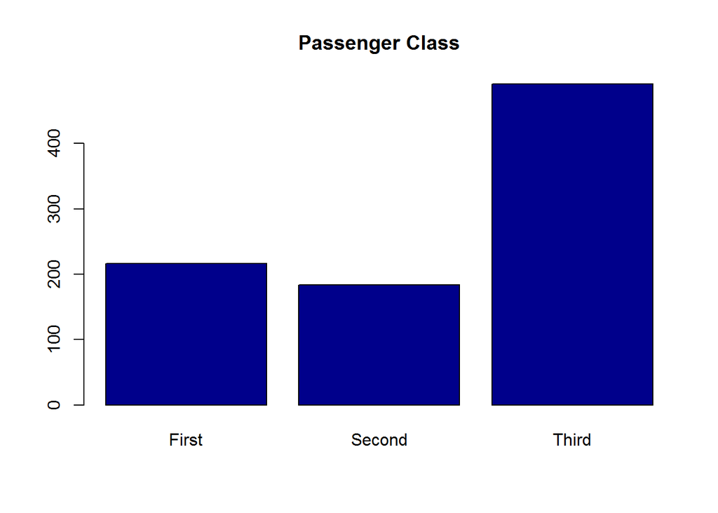

```r
barplot(table(train.data$Pclass), main = "Passenger Class", names = c("First","Second","Third"), col = 'darkblue')
```

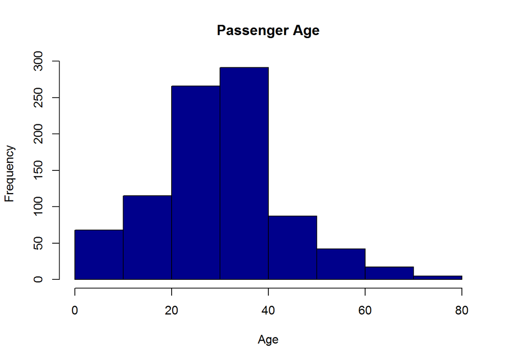

```r
hist(train.data$Age, main = "Passenger Age", xlab = "Age", col = 'darkblue')
```

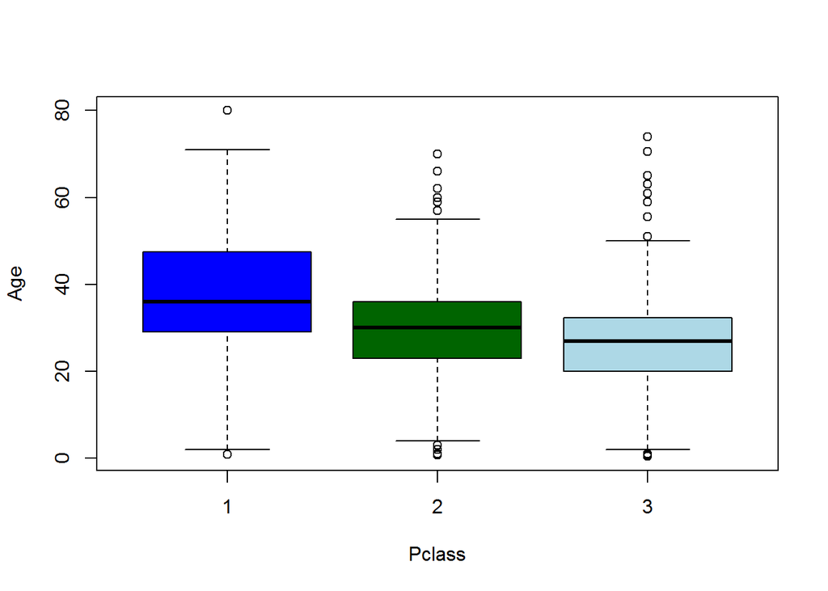

```r
plot(train.data[c("Pclass","Age")], col = c('blue','darkgreen','lightblue'))
```

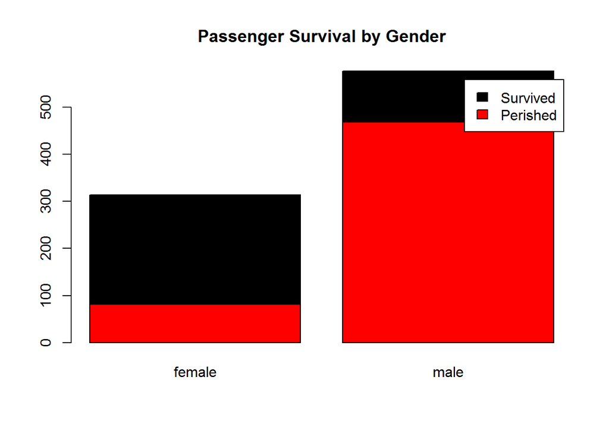

```r
#Lets see who was more likely to survive, men or women
counts = table(train.data$Survived,train.data$Sex)
barplot(counts, col = c("red","black"), legend = c("Perished","Survived"), main = "Passenger Survival by Gender")
```

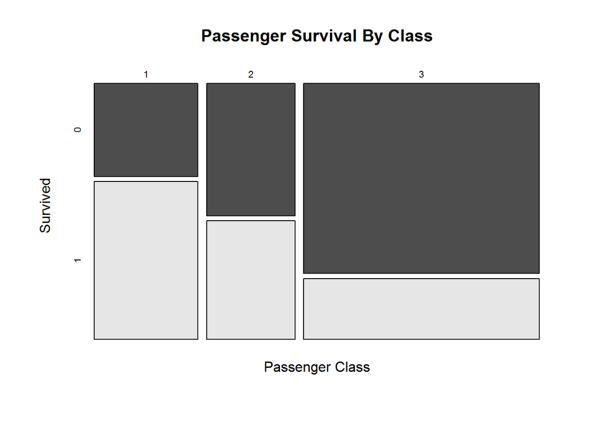

```r
mosaicplot(train.data$Pclass ~ train.data$Survived, main ='Passenger Survival By Class', shade = F,color = T, xlab = 'Passenger Class', ylab = 'Survived')
```

This visualization using support from the caret package is nice because it gives a colored breakdown of the selected predictors.

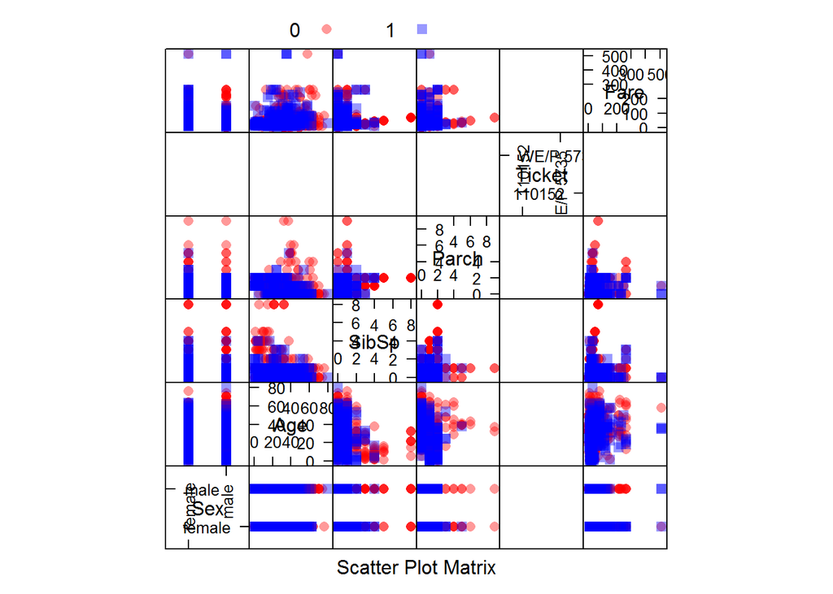

```r
#Fancy visualizations using caret and APM
transparentTheme(trans = .4)
featurePlot(x = combined[, 4:9], y = combined$Survived, plot = "pairs", auto.key = list(columns = 3))
```

As we can see from the visualizations, you were more likely to die if you were male and if you were in the third class. First class made out pretty well! What about age though?

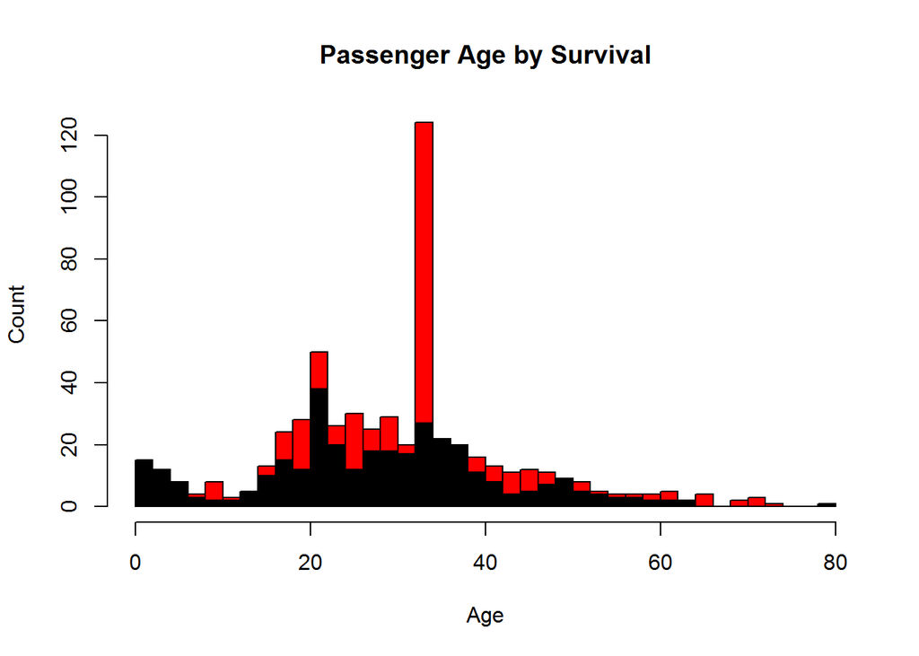

```r
#Black is survived, red is dead.
hist(train.data$Age[which(train.data$Survived == "0")], main = "Passenger Age by Survival", xlab = "Age",ylab = "Count", col = "red", breaks = seq(0,80, by = 2))
hist(train.data$Age[which(train.data$Survived == "1")], add = T, col = "black", breaks = seq(0,80, by = 2))
```

## Prediction using machine learning!

For the models listed below, we use *trainControl* to set cross fold validation to increase the power of our models in predicting the test data. Kappa is also used over Accuracy as a metric due to its ability to be a more robust measure of performance.

### Random forest model first.

```r
#Setting the random seed allows for reproducibility
set.seed(1234)

##Random Forest
#Build a training control variable
ctrl = trainControl(method="repeatedcv", number=10, repeats=3)

rf_model <- train(Survived~Pclass + Sex + Age + SibSp + Parch + FamilySize + Title + Embarked, data = train.data, method = "rf", metric = "Kappa", trControl = ctrl, ntree = 1000)
#Scores .78

#Confusion Matrix and variable importance
pred <- predict(rf_model,train.data)
confusionMatrix(pred, train.data$Survived)
```

```
## Confusion Matrix and Statistics
##
##           Reference
## Prediction   0   1
##          0 492  90
##          1  57 252
##
##                Accuracy : 0.835
##                  95% CI : (0.809, 0.8588)
##     No Information Rate : 0.6162
##     P-Value [Acc > NIR] : < 2.2e-16
##
##                   Kappa : 0.6447
##  Mcnemar's Test P-Value : 0.008307
##
##             Sensitivity : 0.8962
##             Specificity : 0.7368
##          Pos Pred Value : 0.8454
##          Neg Pred Value : 0.8155
##              Prevalence : 0.6162
##          Detection Rate : 0.5522
##    Detection Prevalence : 0.6532
##       Balanced Accuracy : 0.8165
##
##        'Positive' Class : 0
##
```

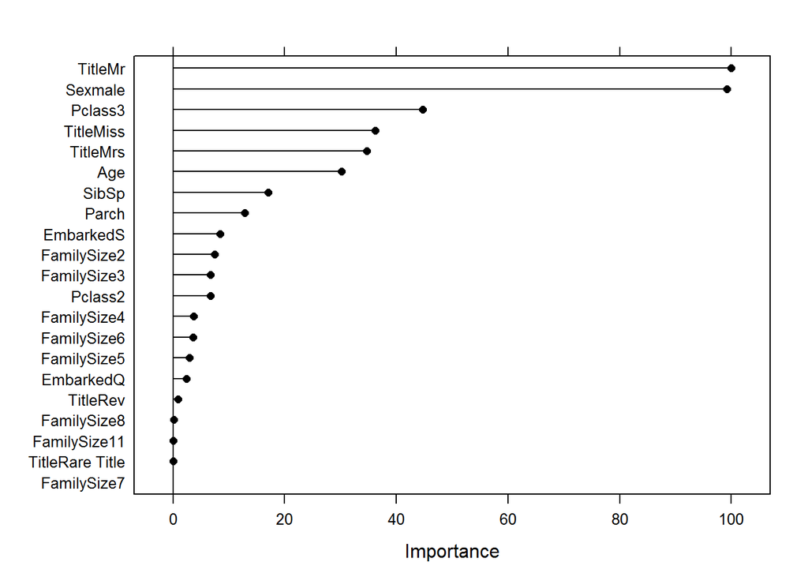

```r
plot(varImp(rf_model))
```

```r
#Prediction against test for submission
pred <- predict(rf_model, test.data)
```

### NNet model

```r
##Nnet
ctrl = trainControl(method="repeatedcv", number=10, repeats=3)
nnet_model <- train(Survived~Pclass + Sex + Age + Title + Embarked + FamilySize + SibSp + Parch, data = train.data, method = "pcaNNet", trControl = ctrl, verbose = F, metric = 'Kappa')
#Scores .799

#Confusion matrix and variable importance
pred <- predict(nnet_model, train.data)
confusionMatrix(pred, train.data$Survived)
```

```
## Confusion Matrix and Statistics
##
##           Reference
## Prediction   0   1
##          0 515  91
##          1  34 251
##
##                Accuracy : 0.8597
##                  95% CI : (0.8352, 0.8819)
##     No Information Rate : 0.6162
##     P-Value [Acc > NIR] : < 2.2e-16
##
##                   Kappa : 0.6938
##  Mcnemar's Test P-Value : 5.477e-07
##
##             Sensitivity : 0.9381
##             Specificity : 0.7339
##          Pos Pred Value : 0.8498
##          Neg Pred Value : 0.8807
##              Prevalence : 0.6162
##          Detection Rate : 0.5780
##    Detection Prevalence : 0.6801
##       Balanced Accuracy : 0.8360
##
##        'Positive' Class : 0
##
```

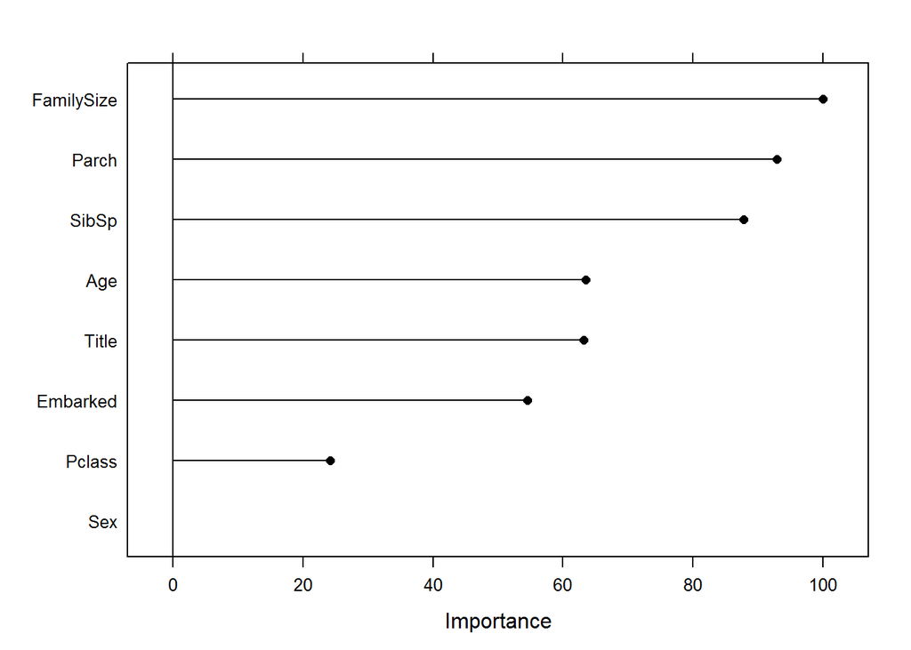

```r
plot(varImp(nnet_model))
```

```r
#Prediction against test for submission
pred <- predict(nnet_model, test.data)
```

Interesting, neural net has completely different variable importance, assigning almost nothing to the Sex variable.

### Adaboost

This model works very well against the training data but performs poorly on the submission data.

```r
set.seed(1748)
ctrl = trainControl(method="repeatedcv", number=5, repeats=2)

ada_model <- train(Survived~Pclass + Sex + Age + Title + FamilySize + Embarked, data = train.data, method = 'adaboost', trControl = ctrl, metric = "Kappa")
#Confusion matrix and variable importance
pred <- predict(ada_model, train.data)
confusionMatrix(pred, train.data$Survived)
```

```
## Confusion Matrix and Statistics
##
##           Reference
## Prediction   0   1
##          0 520  26
##          1  29 316
##
##                Accuracy : 0.9383
##                  95% CI : (0.9204, 0.9532)
##     No Information Rate : 0.6162
##     P-Value [Acc > NIR] : <2e-16
##
##                   Kappa : 0.8697
##  Mcnemar's Test P-Value : 0.7874
##
##             Sensitivity : 0.9472
##             Specificity : 0.9240
##          Pos Pred Value : 0.9524
##          Neg Pred Value : 0.9159
##              Prevalence : 0.6162
##          Detection Rate : 0.5836
##    Detection Prevalence : 0.6128
##       Balanced Accuracy : 0.9356
##
##        'Positive' Class : 0
##
```

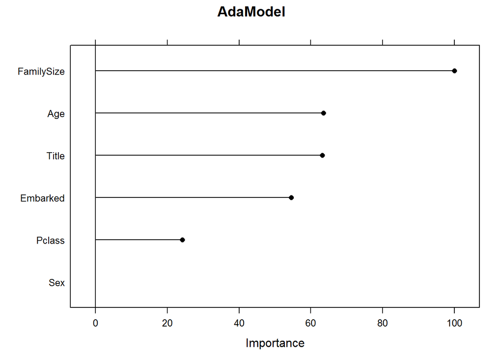

```r
plot(varImp(ada_model), main = 'AdaModel')
```

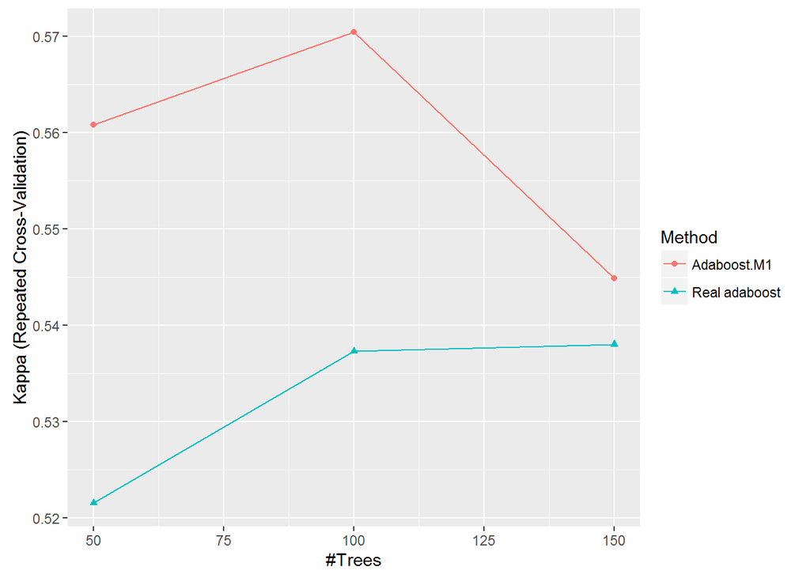

```r
ggplot(ada_model)
```

```r
#Prediction against test for submission
pred <- predict(ada_model, test.data)
```

## Bonus model

### Support Vector Machines

```r
ctrl = trainControl(method="repeatedcv", number=10, repeats=5)

svm_model <- train(Survived~Pclass + Sex + Age + Title + Embarked + FamilySize, data = train.data, method = 'svmPoly',trControl = ctrl, metric = 'Kappa')
#Confusion matrix and variable importance
pred <- predict(svm_model, train.data)
confusionMatrix(pred, train.data$Survived)
```

[output not shown]

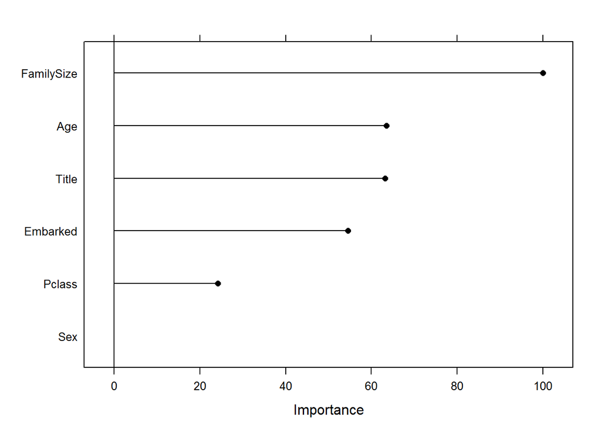

```r
plot(varImp(svm_model))
```

```r
#Prediction against test for submission
pred <- predict(svm_model, test.data)
```

## Submission

We write the submission results to a csv

```r
solution <- data.frame(PassengerID = test.data$PassengerId, Survived = pred)
write.csv(solution, file = "solution.csv", row.names = F)
```